# E05 - Multiple testing issue (Analysis of Gene Expression @ UCT Prague)

Copy, please, these files and directories to your personal directory:

```bash
cp -r ~/shared/AGE_current/Exercises/E05-multiple_testing_issue ~/AGE/Exercises
```

# Introduction

In this tutorial we will show how to control Type I and Type II errors in an experiment that includes multiple simultaneous tests:

- This situation happens very often in functional genomics experiments.
- In a toy model, we will try to identify 100 skewed coins among 1000 coins.

# Assignment

Create a Rmd file `mti.Rmd` and render `mti.html` with the [confusion matrix](https://en.wikipedia.org/wiki/Confusion_matrix) for different p-adjustment methods and cutoff value of 0.05, 0.1 and 0.25.

# Config

Set random seed:

```r
set.seed(111)
```

# Perform the experiment

Flip each coin 100 times in 100 trials and store the mean number of heads in each trial. First the skewed coins, then the fair coins. Represent the prototypic fair coin by expected mean number of heads in 100 trials.

100 skewed coins:

```r
trialsSkew <- lapply(1:100,  function(x) rbinom(n = 100, size = 100, prob = 1/2.1))
trialsSkew[[1]]
```

```
##   [1] 51 52 44 55 49 47 43 49 54 51 45 40 49 44 45 49 46 45 43 44 49 46 46 38 40
##  [26] 45 43 43 47 46 45 62 55 46 50 49 52 52 44 54 55 52 56 49 51 47 45 49 44 47
##  [51] 52 50 47 45 40 45 43 42 49 45 48 47 47 47 38 41 43 40 43 42 52 47 47 61 50
##  [76] 46 39 48 40 48 45 48 50 51 46 55 47 40 40 42 48 43 47 48 53 55 55 57 47 54
```

900 fair coins:

```r
trialsNull <- lapply(1:900,  function(x) rbinom(n = 100, size = 100, prob = 1/2))
trialsNull[[1]]
```

```
##   [1] 49 39 47 51 44 45 50 39 53 47 42 39 48 52 41 55 53 51 49 61 49 52 40 49 48
##  [26] 48 52 49 49 42 46 48 46 53 64 50 51 48 57 50 55 52 38 48 50 46 58 34 55 49
##  [51] 43 49 50 51 48 60 51 46 56 53 48 50 38 57 56 59 48 57 48 49 55 60 38 48 56
##  [76] 53 35 47 54 48 56 49 57 51 47 40 45 55 54 43 49 46 55 52 50 55 49 48 48 49
```

A prototype fair coin:

```r
muTrue <- 1/2 * 100
```

# Statistics

Compare skewed coins and the prototype:

```r
pSkew <- sapply(trialsSkew, function(x) t.test(x, mu = muTrue)$p.value)
```

Compare fair coins and the prototype:

```r
pNull <- sapply(trialsNull, function(x) t.test(x, mu = muTrue)$p.value)
```

All p-values:

```r
p <- c(pSkew, pNull)
```

Observe skewed, uniform, and mixed distribution of p-values:

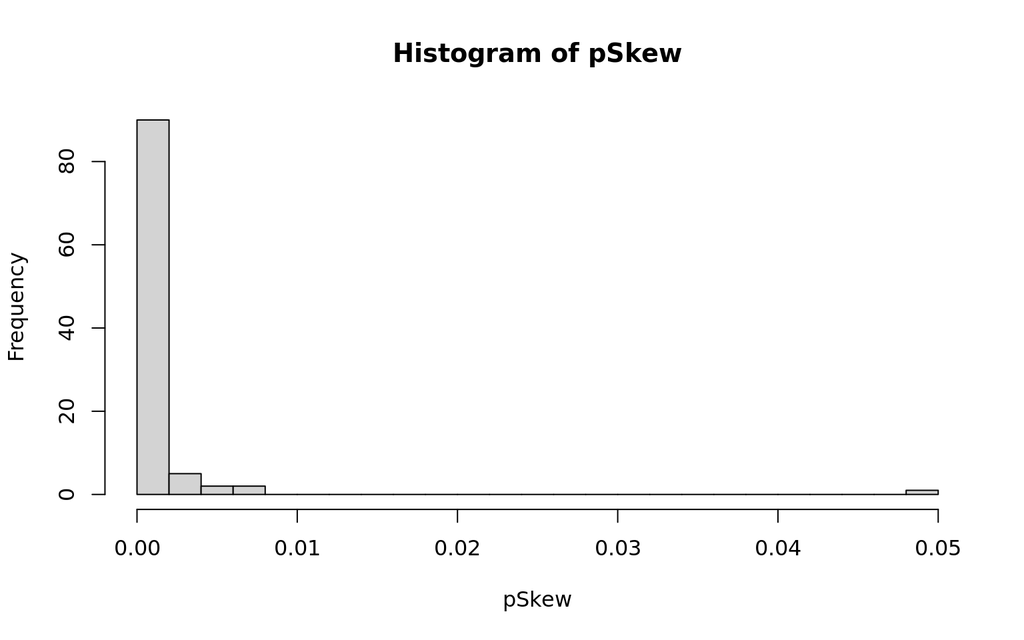

```r
hist(pSkew, breaks = 20)
```

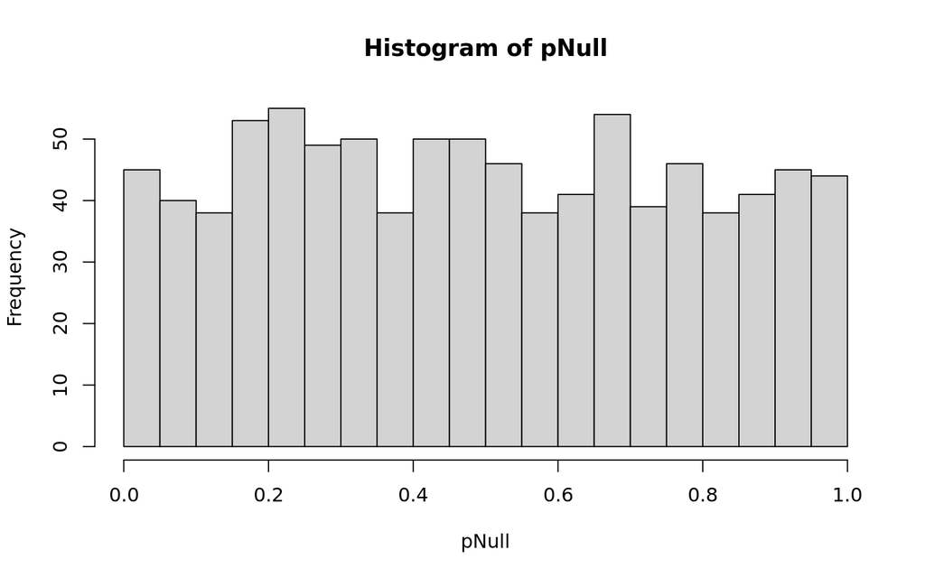

```r
hist(pNull, breaks = 20)
```

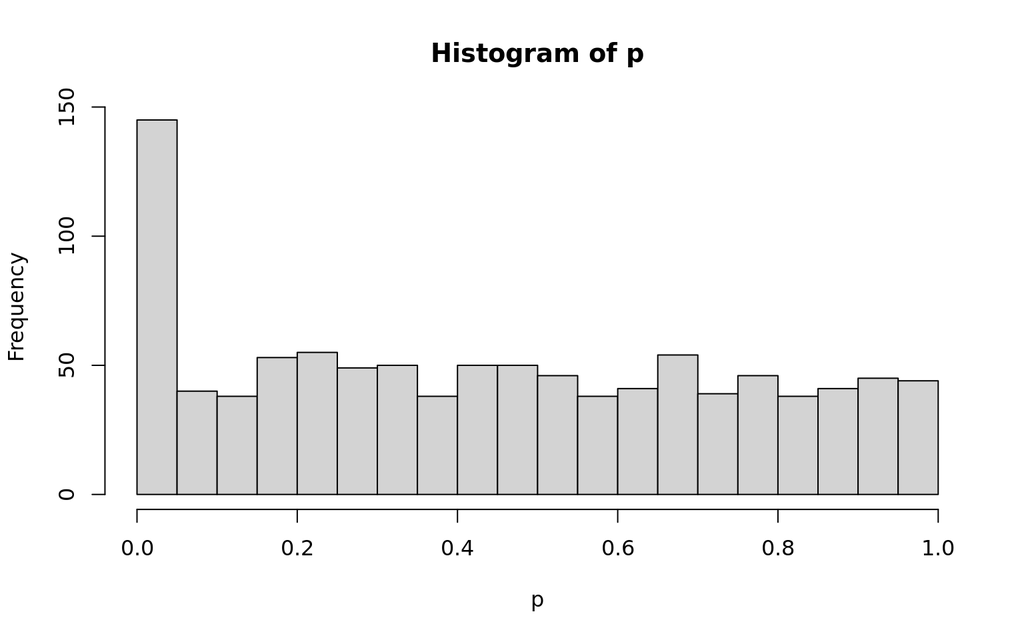

```r
hist(p, breaks = 20)
```

# Multiple testing issue

```r
table(p < 0.05)
```

```
##
## FALSE  TRUE
##   855   145
```

That is many more than the grand truth. The spurious skewed coins come from the fact that roughly 1/20 of the fair coins will have p < 0.05: the 900 p-values of insignificant tests of fair coins to the prototype coin are uniformly distributed.

Let’s adjust the p-values using Bonferroni’s method (family-wise error rate, FWER), Benjamini-Hochberg’s FDR (false discovery rate), and Storey’s q-value (positive FDR):

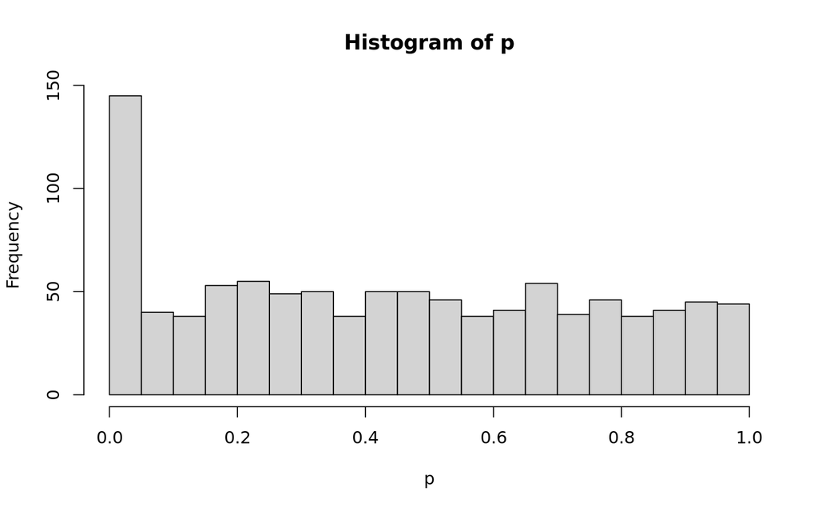

```r
bonferroni <- p.adjust(p, "bonferroni")
fdr <- p.adjust(p, "fdr")
library(qvalue)
q <- qvalue(p)$qvalues

hist(p, breaks = 20)
```

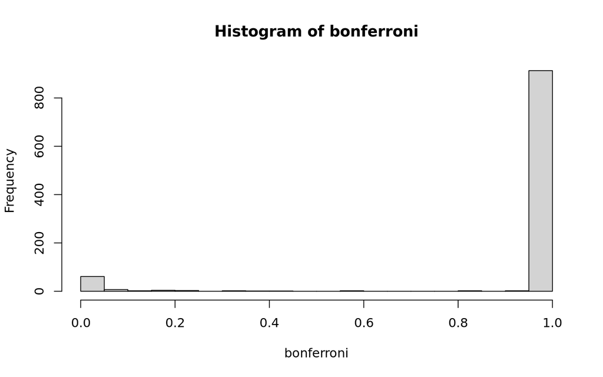

```r
hist(bonferroni, breaks = 20)
```

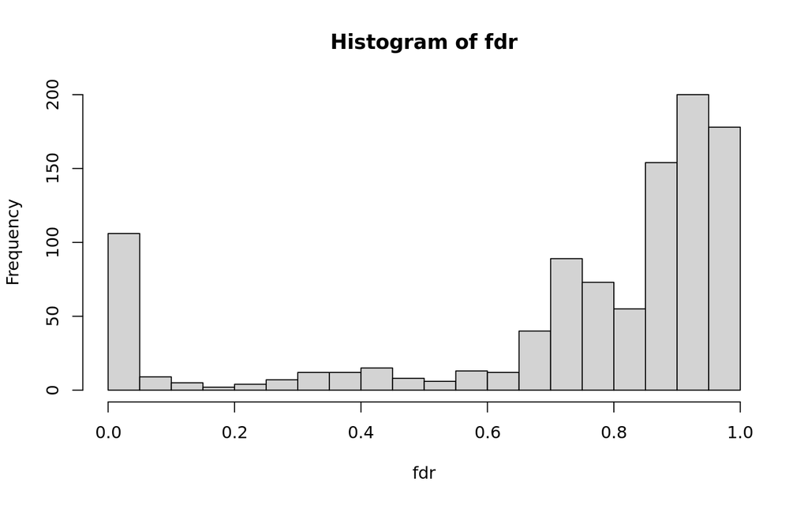

```r
hist(fdr, breaks = 20)
```

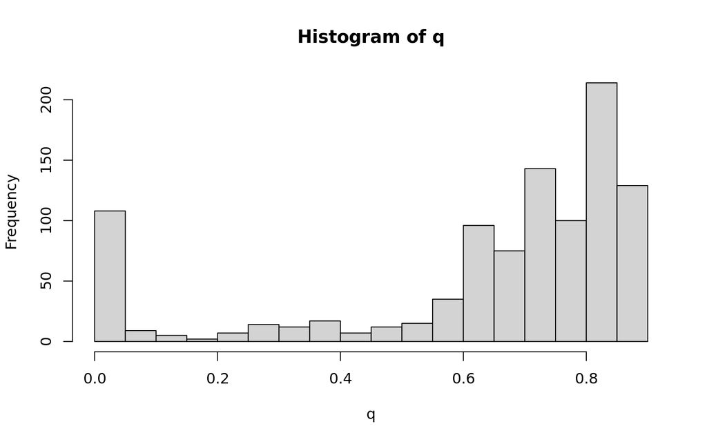

```r
hist(q, breaks = 20)
```

p < 0.05:

```r
table(p < 0.05)
```

```
##
## FALSE  TRUE
##   855   145
```

FWER < 0.05:

```r
table(bonferroni < 0.05)
```

```
##
## FALSE  TRUE
##   939    61
```

FDR < 0.05:

```r
table(fdr < 0.05)
```

```
##
## FALSE  TRUE
##   894   106
```

q < 0.05:

```r
table(q < 0.05)
```

```
##
## FALSE  TRUE
##   892   108
```

We observe that while p-value is overly liberal and FWER overly stringent, FDR and q-value approach the number of skewed coins pretty well. But do we actually find the skewed coins, or just any coins? Can we distinguish the skewed coins by our experiment? Let’s do some plots. In the plots, black coins are fair and skewed coins are green. The first plot shows all the coins, then we zoom in to see mainly the skewed coins.

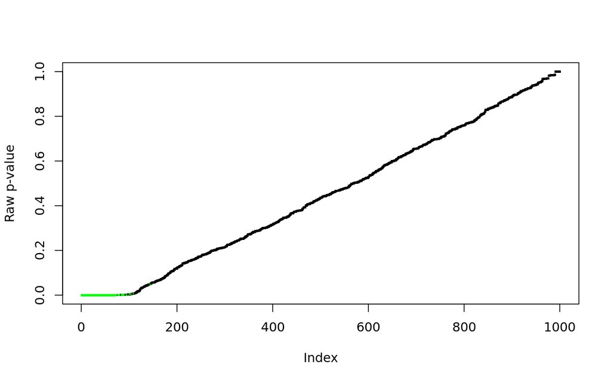

```r
##-- order of the p-values
oq <- order(p)

##-- see selected coins
plot(p[oq], col = c(rep("green", 100), rep("black", 900))[oq], pch = ".", cex = 3, ylab = "Raw p-value")
```

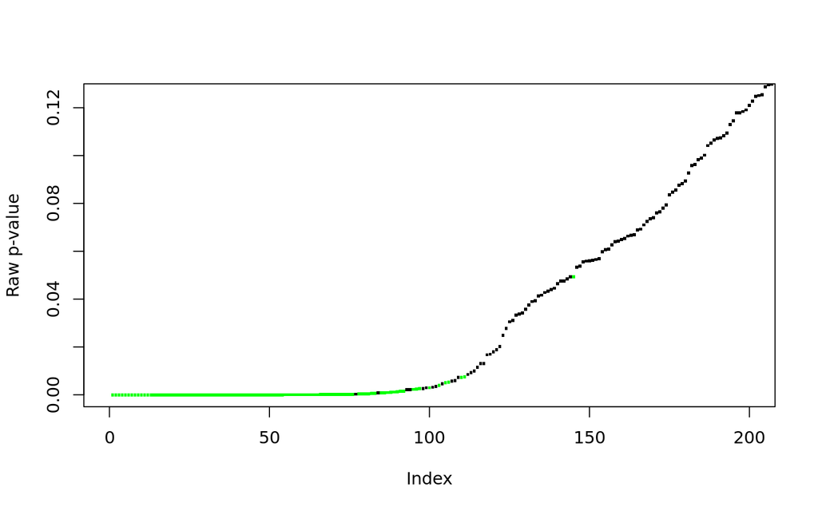

```r
plot(
  p[oq], xlim = c(0, 200), ylim = c(0, 0.125), col = c(rep("green", 100), rep("black", 900))[oq], pch = ".",
  cex = 3, ylab = "Raw p-value"
)
```

The thresholds corresponding to p-value, FWER, and FDR are drawn in dark red, red, and orange, respectively.

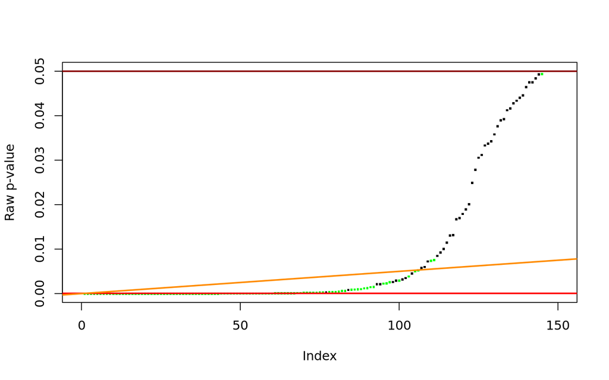

```r
plot(
  p[oq], xlim = c(0, 150), ylim = c(0, 0.05), col = c(rep("green", 100), rep("black", 900))[oq], pch = ".",
  cex = 3, ylab = "Raw p-value"
)

abline(a = 0.05, b = 0, col = "darkred", lwd = 2)
abline(a = 0.05 / 1000, b = 0, col = "red", lwd = 2)
abline(a = 0, b = 0.05 / 1000, col = "darkorange", lwd = 2)
```

As both FDR and q estimate proportion of false discoveries among significant tests, we often set their threshold values to 0.1, having 10 % false discoveries in the resulting list of coins that are deemed skewed.

FDR < 0.1:

```r
table(fdr < 0.1)
```

```
##
## FALSE  TRUE
##   885   115
```

q < 0.1:

```r
table(q < 0.1)
```

```
##
## FALSE  TRUE
##   883   117
```

# Cleanup

```r
save(list = ls(all.names = TRUE), file = here("E05-multiple_testing_issue/multiple_testing_issue.RData"), envir = environment())

warnings()
traceback()
```

```
## No traceback available
```

# HTML rendering

This chunk is not evaluated (`eval = FALSE`). Otherwise you will probably end up in recursive hell 🤯

```r
library(conflicted)
library(knitr)
library(here)

if (!require(rmdformats)) {
  BiocManager::install("rmdformats")
}

# You can set global chunk options. Options set in individual chunks will override this.
opts_chunk$set(warning = FALSE, message = FALSE, eval = TRUE)
rmarkdown::render(
  here("E05-multiple_testing_issue/multiple_testing_issue.Rmd"),
  output_file = here("E05-multiple_testing_issue/multiple_testing_issue.html"),
  envir = new.env(),
  knit_root_dir = here()
)
```